# V2_Phytocosm_Experiment

author: “Quentin Schorpp” e-mail: quentin.schorpp@ti.bund.de date: “Tuesday, October 21, 2014” output: html_document

#### Set working directory

```r
# setwd("E:\Quentin Schorpp_17.10.2014\Arbeitsprozess\V2_Analysis")
# here it is important, that you change this path:
# go to the folder were you put the data in and click in the address line to copy YOUR path
# alternatively you can use :
# setwd(choose.dir())
```

#### Load required packages

```r
library(ggplot2)
library(reshape2)
library(plyr)
library(MethComp)
library(agricolae)
library(foreign)
library(multcomp)
library(gridExtra)
library(extrafont)
library(effects)
```

#### Function for Standard error

```r
se <- function(x) sqrt(var(x)/length(x))
```

#### load datasets

```r
Lt.bm.loam <- read.delim("Lt_bm_loam.txt")
Lt.bm <- read.delim("Lt_bm.txt")
```

# L. terrestris survival rate and biomass

## Survival rate:

#### In the sandy soil experiment 6 out of 40 worms died in 3 Phytocosms

#### survival rate sand: 85%

#### In the loamy soil experiment overall out of 41 out of 78 worms survived the experiment.

#### survival rate loam: 52.5641026%

## Loamy soil only

Here it is a bit difficult, because many worms died at different timepoints during the loamy soil experiment, due to extreme temperatures. And we don't know, which worm was replaced, therfore its impossible to calculate the true total biomass after replacement of any worm. But for maitainig the earthwrom-effect it was inevitably necessary to replace the worms.

The dataset: The data set has different responses, all of which were calculated using the individual worm weights, not the total biomass per Phytocosm. first and easiest ist Lt.ind.mean, this is simply the difference in mean individual weights of worms taken out from mean individual weights of worms given in. Because we simply can't differentiate between worms, we can#t exactly say, which worm gained weight on which one lost. Therfore, i calculated all possible differences between worms taken out and those given in. Based on these differences i calculated the ratio between weight gain (positive) and weight loss (negative). Here zero means only losses, Inf only gains and 1 same counts for both (neutral). Another reponse is the calculated probaility of getting only weight gain by drawing wihtout return. Then there is a factor of three levels (positive, neutral and negative), for ratios above and beyond 1. Last but not least there is the means in all possible differences.

The Analysis: The procedure is to formulate the model for ANOVA and then validate the model, i.e. to check if the assumptions of ANOVA are violated or not. To visualize the significant effects from the ANOVA table we use Boxplots.

```r
Lt.bm.loam.aov <- lbl.aov1 <- aov(pos.diff.mean ~ plant*treat, data=Lt.bm.loam) ; summary(lbl.aov1)
```

```
##             Df Sum Sq Mean Sq F value Pr(>F)
## plant        1 1.1055  1.1055   5.851 0.0278 *
## treat        1 0.0575  0.0575   0.305 0.5887
## plant:treat  1 0.1941  0.1941   1.027 0.3259
## Residuals   16 3.0229  0.1889
## ---
## Signif. codes:  0 '***' 0.001 '**' 0.01 '*' 0.05 '.' 0.1 ' ' 1
```

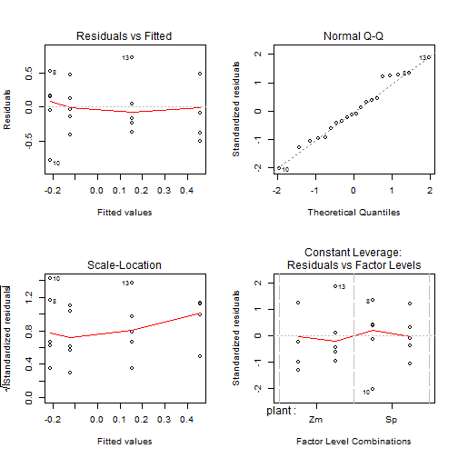

```r
par(mfrow=c(2,2))
plot(lbl.aov1)
```

```r
fligner.test(pos.diff.mean ~ plant*treat, data=Lt.bm.loam)
```

```
##
##  Fligner-Killeen test of homogeneity of variances
##
## data:  pos.diff.mean by plant by treat
## Fligner-Killeen:med chi-squared = 0.307, df = 1, p-value = 0.5795
```

```r
# performs Fligner-Killeen (median) test of homogeneity of variances, to test if there is significant violence of homoscedasticity in each of the groups. If this test has a not significant p-value, there is no clue for violence of this assumption in ANOVA. We could have performed bartlett test, but this is more a test of non-normality.
# --> p=0.58 our ANOVA is good, and we do not need to transform the response.

lbl.aov2 <- aov(pos.prob ~ plant*treat, data=Lt.bm.loam)
fligner.test(pos.prob ~ plant*treat, data=Lt.bm.loam)
```

```
##
##  Fligner-Killeen test of homogeneity of variances
##
## data:  pos.prob by plant by treat
## Fligner-Killeen:med chi-squared = 12.3625, df = 1, p-value =
## 0.000438
```

```r
# here the model is not adequate!!
lbl.aov2 <- update(lbl.aov2, sqrt(pos.prob)~.); summary(lbl.aov2)
```

```
##             Df Sum Sq Mean Sq F value Pr(>F)
## plant        1 0.4697  0.4697   4.874 0.0422 *
## treat        1 0.0373  0.0373   0.388 0.5424
## plant:treat  1 0.0015  0.0015   0.015 0.9037
## Residuals   16 1.5418  0.0964
## ---
## Signif. codes:  0 '***' 0.001 '**' 0.01 '*' 0.05 '.' 0.1 ' ' 1
```

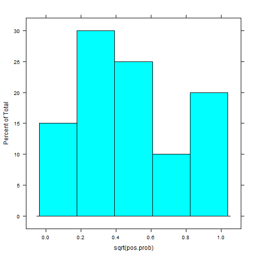

```r
with(Lt.bm.loam, histogram(sqrt(pos.prob)))
```

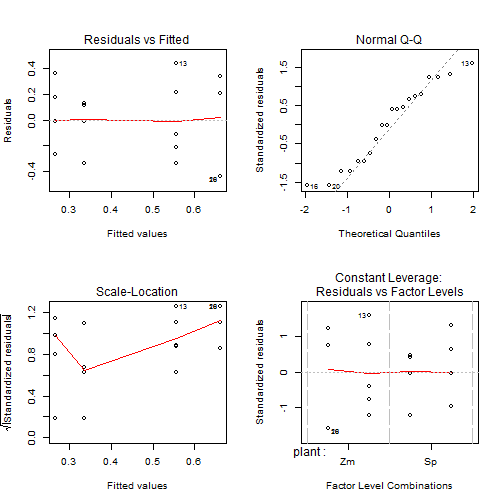

```r
par(mfrow=c(2,2))
plot(lbl.aov2)
```

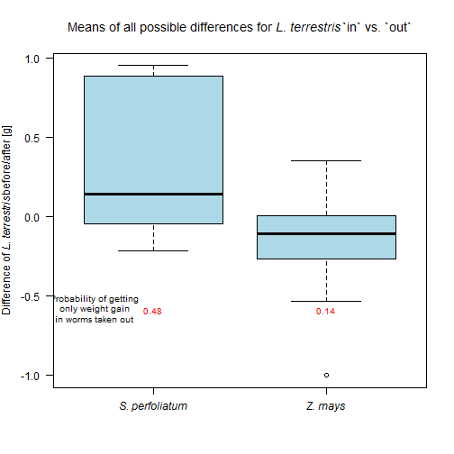

```r
# Ok, here its too much effort to find out how to handle response variables of class "probabilities",... validation plots don't look too bad, so i'll let it be


boxplot(pos.diff.mean ~ plant,
        data=Lt.bm.loam, col="light blue", las=1, par(mfrow=c(1,1)),
        main = expression(paste("Means of all possible differences for ", italic("L. terrestris"), "`in` vs. `out`")),
        ylab = expression(paste("Difference of ", italic("L. terrestris"), "before/after [g]")),
        names=c(expression(italic("S. perfoliatum"),italic("Z. mays")))
        )
text(x=c(1,2),y=min(boxplot.stats(Lt.bm.loam$pos.diff.mean)$stat), round(with(Lt.bm.loam, data.frame(tapply(pos.prob, plant, mean)))[,1],2), pos=3, offset=-1, cex=.8, col="red")
text(x=1-0.34,y=min(boxplot.stats(Lt.bm.loam$pos.diff.mean)$stat), paste("Probability of getting\nonly weight gain\nin worms taken out"), pos=3, offset=-1.6, cex=.8)
```

```r
# from the above analysis we get secure evidence, that earthworms are likely to have better growth conditions in S. perfoliatum phytocosms, wether this is due to higher quality nutrition of Silphie litter, or lower energy cost while moving inside of these microcosms (decreased bulk densitiy due to Silphie roots?), is to discuss.

lbl.aov3 <- aov(ind.bm.mean ~ plant*treat, data=Lt.bm.loam); summary(lbl.aov3)
```

```
##             Df Sum Sq Mean Sq F value Pr(>F)
## plant        1  1.647  1.6471   7.769 0.0132 *
## treat        1  0.058  0.0579   0.273 0.6084
## plant:treat  1  0.210  0.2103   0.992 0.3341
## Residuals   16  3.392  0.2120
## ---
## Signif. codes:  0 '***' 0.001 '**' 0.01 '*' 0.05 '.' 0.1 ' ' 1
```

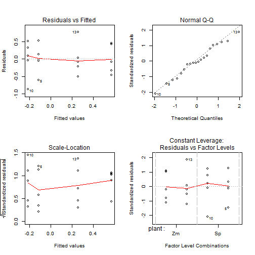

```r
par(mfrow=c(2,2))
plot(lbl.aov3)
```

```r
fligner.test(ind.bm.mean ~ plant*treat, data=Lt.bm.loam)
```

```
##
##  Fligner-Killeen test of homogeneity of variances
##
## data:  ind.bm.mean by plant by treat
## Fligner-Killeen:med chi-squared = 0.1117, df = 1, p-value = 0.7382
```

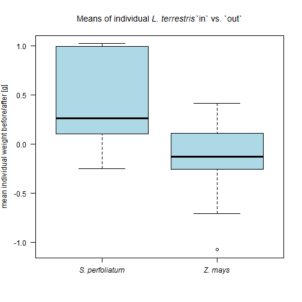

```r
boxplot(ind.bm.mean ~ plant,
        data=Lt.bm.loam, col="light blue", las=1, par(mfrow=c(1,1)),
        main = expression(paste("Means of individual ", italic("L. terrestris"), "`in` vs. `out`")),
        ylab = expression(paste("mean individual weight before/after [g]")),
        names=c(expression(italic("S. perfoliatum"),italic("Z. mays")))
        )
```

```r
with(Lt.bm.loam, data.frame(tapply(ind.bm.mean, plant, mean)))
```

```
##    tapply.ind.bm.mean..plant..mean.
## Sp                        0.4112492
## Zm                       -0.1626947
```

```r
with(Lt.bm.loam, data.frame(tapply(ind.bm.mean, plant, se)))
```

```
##    tapply.ind.bm.mean..plant..se.
## Sp                      0.1439014
## Zm                      0.1412798
```

```r
# from ANOVA we get a significant difference in earthworm mean individual weight of L. terrestris for plant species (ANOVA; F=7.8; p=0.01). In phytocosm

#These responses didn't work in ANOVA:
#summary(aov(pos.diff.ratio ~ plant*treat, data=Lt.bm.loam))
#summary(aov(pos.diff.fac ~ plant*treat, data=Lt.bm.loam))
```

## Loamy and sandy soil texture gathered together

from above we learned, that we can trust the results by using the average individual weights of L. terrestris. Therefore I produced a dataset with the average individuals weights for all worms from both, the loamy and the sandy soil experiment. The dataset consists of the mean individual weights of all worms given in (before) and all those taken out (after) as well as the differences between after and before.

```r
which(Lt.bm$Lt.bm.diff==0)
```

```
## [1] 21 30 33
```

```r
Lt.bm.aov1 <- aov(Lt.bm.diff~plant*Lt*Fc*soil, Lt.bm[-c(21,30,33),]); summary(Lt.bm.aov1)
```

```
##               Df Sum Sq Mean Sq F value   Pr(>F)
## plant          1  3.530   3.530  24.469 2.94e-05 ***
## Fc             1  0.004   0.004   0.028    0.868
## soil           1  0.136   0.136   0.945    0.339
## plant:Fc       1  0.361   0.361   2.500    0.125
## plant:soil     1  0.009   0.009   0.063    0.804
## Fc:soil        1  0.124   0.124   0.860    0.362
## plant:Fc:soil  1  0.000   0.000   0.001    0.979
## Residuals     29  4.184   0.144
## ---
## Signif. codes:  0 '***' 0.001 '**' 0.01 '*' 0.05 '.' 0.1 ' ' 1
```

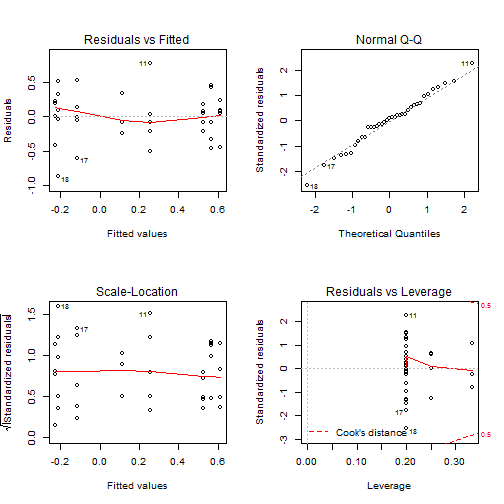

```r
par(mfrow=c(2,2))
plot(Lt.bm.aov1)
```

```r
fligner.test(Lt.bm.diff~plant*Lt*Fc*soil, Lt.bm[-c(21,30,33),])
```

```
##
##  Fligner-Killeen test of homogeneity of variances
##
## data:  Lt.bm.diff by plant by Lt by Fc by soil
## Fligner-Killeen:med chi-squared = 0.0216, df = 1, p-value = 0.8833
```

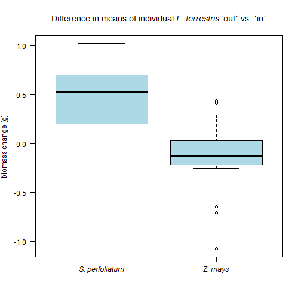

```r
# Model is valid!

boxplot(Lt.bm.diff ~ plant,
        data=Lt.bm[-c(21,30,33),], col="light blue", las=1, par(mfrow=c(1,1)),
        main = expression(paste("Difference in means of individual ", italic("L. terrestris"), "`out` vs. `in`")),
        ylab = expression(paste("biomass change [g]")),
        names=c(expression(italic("S. perfoliatum"),italic("Z. mays")))
        )
```

```r
with(Lt.bm[-c(21,30,33),], data.frame(Diff.Mean = tapply(Lt.bm.diff, plant, mean),
                       Diff.SE = tapply(Lt.bm.diff, plant, se),
                       Before.Mean = tapply(Lt.bm.before, plant, mean),
                       Before.SE = tapply(Lt.bm.before, plant, se),
                       After.Mean = tapply(Lt.bm.after, plant, mean),
                       After.SE = tapply(Lt.bm.after, plant, se)))
```

```
##     Diff.Mean    Diff.SE Before.Mean  Before.SE After.Mean   After.SE
## Sp  0.4901996 0.07886842    3.026165 0.02864253   3.520718 0.08524326
## Zm -0.1295910 0.09498789    3.130792 0.02927611   3.020570 0.10151632
```